# **Predicting a Win in League of Legends**

## David Koss

League of Legends is a massive MOBA (Multiplayer Online Battle Arena). Essentially a 5v5 roleplaying game where you can play as Champions of the arena in select roles. The point of the game is to attack and destroy the enemy Nexus. The first team to dstroy the other teams Nexus wins the game. However, it can take time to get to the enemy Nexus. Having to push through enemy turrets, and inhibitors. There are also "neutral" objectives throughout the map which give your team buffs if killed. Our goal is to take the given data provided from Leagues API, and predict a win given fields such as first blood. For more information about League of Legends, you can visit their [wiki](https://leagueoflegends.fandom.com/wiki/League_of_Legends_Wiki) page. The data from my dataset can be found here: https://www.kaggle.com/datasets/datasnaek/league-of-legends?select=games.csv

# **Data Collection & Management**

```python
# Name: David Koss
# Class: CMSC422 Spring 2023

import pandas as pd
import numpy as np
import seaborn as sns
import mpld3
import matplotlib.pyplot as plt
from sklearn import linear_model
from sklearn import model_selection
import scipy.stats as stats
import plotly.io as pio
from sklearn.tree import DecisionTreeClassifier
from sklearn.linear_model import LinearRegression

# Get our data
data = pd.read_csv("https://raw.githubusercontent.com/dkosss/finalproj_data/main/games.csv")

data
```

|  | gameId | creationTime | gameDuration | seasonId | winner | firstBlood | firstTower | firstInhibitor | firstBaron | firstDragon | ... | t2_towerKills | t2_inhibitorKills | t2_baronKills | t2_dragonKills | t2_riftHeraldKills | t2_ban1 | t2_ban2 | t2_ban3 | t2_ban4 | t2_ban5 |
| --- | --- | --- | --- | --- | --- | --- | --- | --- | --- | --- | --- | --- | --- | --- | --- | --- | --- | --- | --- | --- | --- |
| 0 | 3326086514 | 1504279457970 | 1949 | 9 | 1 | 2 | 1 | 1 | 1 | 1 | ... | 5 | 0 | 0 | 1 | 1 | 114 | 67 | 43 | 16 | 51 |
| 1 | 3229566029 | 1497848803862 | 1851 | 9 | 1 | 1 | 1 | 1 | 0 | 1 | ... | 2 | 0 | 0 | 0 | 0 | 11 | 67 | 238 | 51 | 420 |
| 2 | 3327363504 | 1504360103310 | 1493 | 9 | 1 | 2 | 1 | 1 | 1 | 2 | ... | 2 | 0 | 0 | 1 | 0 | 157 | 238 | 121 | 57 | 28 |
| 3 | 3326856598 | 1504348503996 | 1758 | 9 | 1 | 1 | 1 | 1 | 1 | 1 | ... | 0 | 0 | 0 | 0 | 0 | 164 | 18 | 141 | 40 | 51 |
| 4 | 3330080762 | 1504554410899 | 2094 | 9 | 1 | 2 | 1 | 1 | 1 | 1 | ... | 3 | 0 | 0 | 1 | 0 | 86 | 11 | 201 | 122 | 18 |
| ... | ... | ... | ... | ... | ... | ... | ... | ... | ... | ... | ... | ... | ... | ... | ... | ... | ... | ... | ... | ... | ... |
| 51485 | 3308904636 | 1503076540231 | 1944 | 9 | 2 | 1 | 2 | 2 | 0 | 2 | ... | 10 | 2 | 0 | 4 | 0 | 55 | -1 | 90 | 238 | 157 |
| 51486 | 3215685759 | 1496957179355 | 3304 | 9 | 2 | 1 | 1 | 2 | 2 | 2 | ... | 11 | 7 | 4 | 4 | 1 | 157 | 55 | 119 | 154 | 105 |
| 51487 | 3322765040 | 1504029863961 | 2156 | 9 | 2 | 2 | 2 | 2 | 0 | 1 | ... | 10 | 2 | 0 | 2 | 0 | 113 | 122 | 53 | 11 | 157 |
| 51488 | 3256675373 | 1499562036246 | 1475 | 9 | 2 | 2 | 2 | 2 | 0 | 2 | ... | 11 | 3 | 0 | 1 | 0 | 154 | 39 | 51 | 90 | 114 |
| 51489 | 3317333020 | 1503612754059 | 1445 | 9 | 1 | 1 | 1 | 1 | 1 | 2 | ... | 1 | 0 | 0 | 1 | 0 | 11 | 157 | 141 | 31 | 18 |

51490 rows × 61 columns

Here we're given a set of data with many different columns ranging from game duration (in seconds) to things like firstDragon. For the purpose of this data, 1 will be referred to as team 1, and 2 will equal the second team. So for example, winner of our first entry was "1" meaning team 1 was the winner of that match. Likewise, objectives like the "firstBaron" will have the same number format, but a "0" will refer to none. For more general info, again visiting this link [League Data](https://www.kaggle.com/datasets/datasnaek/league-of-legends?select=games.csv) will provide all of handy information you need to know about this data.

```python
# Getting rid of data we don't need

new_data = data.drop(["gameId", "creationTime", "t1_champ1id", "t1_champ1_sum1",	"t1_champ1_sum2",	"t1_champ2id",	"t1_champ2_sum1",	"t1_champ2_sum2",	"t1_champ3id",	"t1_champ3_sum1",	"t1_champ3_sum2",	"t1_champ4id",
                      "t1_champ4_sum1",	"t1_champ4_sum2",	"t1_champ5id",	"t1_champ5_sum1",	"t1_champ5_sum2", "t1_ban1",	"t1_ban2",	"t1_ban3",	"t1_ban4",	"t1_ban5",	"t2_champ1id", "t2_champ1_sum1",	"t2_champ1_sum2",
                      "t2_champ2id",	"t2_champ2_sum1",	"t2_champ2_sum2",	"t2_champ3id", "t2_champ3_sum1",	"t2_champ3_sum2", "t2_champ4id",	"t2_champ4_sum1",	"t2_champ4_sum2",	"t2_champ5id",	"t2_champ5_sum1",
                      "t2_champ5_sum2", "t2_ban1",	"t2_ban2",	"t2_ban3",	"t2_ban4",	"t2_ban5", "seasonId"], axis = 1)

# Get the indices of rows where the "winner" column is 0
indices_to_drop = new_data[new_data["winner"] == 0].index

# Drop those rows
new_data.drop(indices_to_drop, inplace = True)

# Drop rows where the "firstBlood" column is 0
new_data.drop(new_data[new_data["firstBlood"] == 0].index, inplace = True)

# Drop rows where the "firstTower" column is 0
new_data.drop(new_data[new_data["firstTower"] == 0].index, inplace = True)

new_data
```

|  | gameDuration | winner | firstBlood | firstTower | firstInhibitor | firstBaron | firstDragon | firstRiftHerald | t1_towerKills | t1_inhibitorKills | t1_baronKills | t1_dragonKills | t1_riftHeraldKills | t2_towerKills | t2_inhibitorKills | t2_baronKills | t2_dragonKills | t2_riftHeraldKills |
| --- | --- | --- | --- | --- | --- | --- | --- | --- | --- | --- | --- | --- | --- | --- | --- | --- | --- | --- |
| 0 | 1949 | 1 | 2 | 1 | 1 | 1 | 1 | 2 | 11 | 1 | 2 | 3 | 0 | 5 | 0 | 0 | 1 | 1 |
| 1 | 1851 | 1 | 1 | 1 | 1 | 0 | 1 | 1 | 10 | 4 | 0 | 2 | 1 | 2 | 0 | 0 | 0 | 0 |
| 2 | 1493 | 1 | 2 | 1 | 1 | 1 | 2 | 0 | 8 | 1 | 1 | 1 | 0 | 2 | 0 | 0 | 1 | 0 |
| 3 | 1758 | 1 | 1 | 1 | 1 | 1 | 1 | 0 | 9 | 2 | 1 | 2 | 0 | 0 | 0 | 0 | 0 | 0 |
| 4 | 2094 | 1 | 2 | 1 | 1 | 1 | 1 | 0 | 9 | 2 | 1 | 3 | 0 | 3 | 0 | 0 | 1 | 0 |
| ... | ... | ... | ... | ... | ... | ... | ... | ... | ... | ... | ... | ... | ... | ... | ... | ... | ... | ... |
| 51485 | 1944 | 2 | 1 | 2 | 2 | 0 | 2 | 0 | 2 | 0 | 0 | 0 | 0 | 10 | 2 | 0 | 4 | 0 |
| 51486 | 3304 | 2 | 1 | 1 | 2 | 2 | 2 | 2 | 5 | 4 | 0 | 2 | 0 | 11 | 7 | 4 | 4 | 1 |
| 51487 | 2156 | 2 | 2 | 2 | 2 | 0 | 1 | 0 | 0 | 0 | 0 | 1 | 0 | 10 | 2 | 0 | 2 | 0 |
| 51488 | 1475 | 2 | 2 | 2 | 2 | 0 | 2 | 0 | 0 | 0 | 0 | 0 | 0 | 11 | 3 | 0 | 1 | 0 |
| 51489 | 1445 | 1 | 1 | 1 | 1 | 1 | 2 | 0 | 11 | 3 | 1 | 2 | 0 | 1 | 0 | 0 | 1 | 0 |

50277 rows × 18 columns

For the purposes of this tutorial, we don't really care about some of the information given in our dataset. Again, we're trying to predict a win with our current data and we want to do this in the most efficient and simplest manner possible. So I went ahead and omitted a few of the columns I didn't feel would help us in achieving this goal and added this new dataset under a variable named "new_data" because I didn't want to completely scrap the original data. These columns were creationTime, gameId, and so forth, there were a lot of entries that were omitted, to see the full list, the code above will show. One thing to also note is I omitted some columns such as team bans and team champion picks. These pieces of data definitely do help us, however it gets very complex and certain things like "metas" will change how effective these columns actually are. So for the purposes of this tutorial, we will focus on things in game, which are much less variable and more binary, such as first blood, first tower, first inhibitor, etc. We've reduced our column size from 61 to 18. We also wanted to remove rows where there was a 0 in the winner column or a 0 in the first blood column, or first tower column. Since a 0 = none, this shows that the game was not played out, or a forfeit had happened in the early stages, which would end up skewing our data. We have now just gone from 51490 rows to 50277 rows. That's a lot of excess data we've omitted!

# **Exploratory Data**

Now we've entered the part in our tutorial in which we would like to start analyzing our data. We will start by breaking down different factors into win ratios. We will use graphs to get a nice visual output at what exactly we are looking at.

**Winner vs First Blood**

First blood in a game is achieved by the very first kill of the game happening. It can award the player getting first blood an additional 400 gold and giving them an advantage in item swiftness. More information on first blood can be found [here](https://www.pinnacle.com/en/esports-hub/betting-articles/league-of-legends/betting-on-first-blood/sgajzgnuz8lgxujv#:~:text=First%20Blood%2C%20abbreviated%20%27FB%27,evenly%20between%20players%20that%20assist.).

```
Win percentage of Team 1: 60.21 %
Win percentage of Team 2: 57.87 %
```

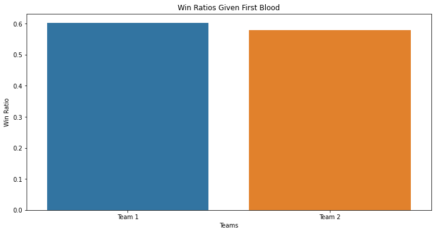

```python
# Correlate first blood with the team that won the game

# Calculate the win ratio for Team 1 ---------------------------------

# Get rows where winner and firstBlood are "1"
team1_data = new_data.loc[(new_data["winner"] == 1) & (new_data["firstBlood"] == 1)]

# Get rows to show how many wins team 1 had
team1_wins = new_data.loc[(new_data["winner"] == 1)]

# Get the numerator and denominator for the win ratio (this is done through the number of rows for each dataframe)
numerator = team1_data.shape[0]
denominator = team1_wins.shape[0]

# Calculate the win ratio
win_ratio_t1 = numerator / denominator


# Calculate the win ratio for Team 2 ---------------------------------

# Get rows where winner and firstBlood are "2"
team2_data = new_data.loc[(new_data["winner"] == 2) & (new_data["firstBlood"] == 2)]

# Get rows to show how many wins team 2 had
team2_wins = new_data.loc[(new_data["winner"] == 2)]

# Get the numerator and denominator for the win ratio (this is done through the number of rows for each dataframe)
numerator = team2_data.shape[0]
denominator = team2_wins.shape[0]

# Calculate the win ratio
win_ratio_t2 = numerator / denominator

# Create a DataFrame with the win ratios
df = pd.DataFrame({'Teams': ['Team 1', 'Team 2'], 'Win Ratio': [win_ratio_t1, win_ratio_t2]})

# Create a bar plot showing the win ratio for each group
plt.figure(figsize = (12, 6))

# Create a bar plot
barplot = sns.barplot(x ='Teams', y ='Win Ratio', data = df)

# Set the title for the bar graph
plt.title("Win Ratios Given First Blood")

# Set the y-axis label
plt.ylabel('Win Ratio')

# Set the x-axis label
plt.xlabel('Teams')

# Show win percentages of each team given first tower
print("Win percentage of Team 1:", round(win_ratio_t1*100, 2), "%")
print("Win percentage of Team 2:", round(win_ratio_t2*100, 2), "%")

# To make graphs showable on the HTML document
pio.renderers.default = 'notebook'
```

Here we can see that if team 1 got first blood, then they were more likely to win the match and same with team 2. Specifically, team 1 had about a **0.60 win ratio** after getting first blood. If team 2 got first blood, then they had approximately a **0.58 win ratio**. This data tells us that the **team getting first blood was more likely to win** the match given that both values are above 50%. The win ratio was calculated as follows, a win for a team is counted as a win if the row in columns "winner" and "firstBlood" are both matching. This means for example, if entry 7 has a "1" in the "winner" column and a "1" in the "firstBlood" column, then this would be a win for team 1. Then this was divided by the total number of games won by team 1. So the only difference to keep track of here, is the "win" definition we use, so we can calculate the win ratio given that team got first blood.

**Winner vs First Tower**

First Tower in League of Legends is getting the first tower in the game. This awards the player and team both map positioning and bonus gold for destroying it. More information on first tower (or turret) can be found [here](https://leagueoflegends.fandom.com/wiki/Turret).

[figure not shown]

```
Win percentage of Team 1: 71.99 %
Win percentage of Team 2: 69.63 %
```

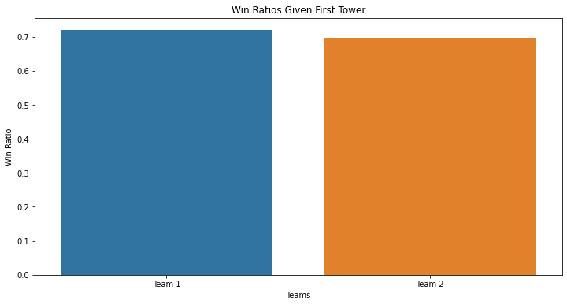

```python
# Calculate the win ratio for Team 1 ---------------------------------

# Get rows where winner and firstTower are "1"
team1_data = new_data.loc[(new_data["winner"] == 1) & (new_data["firstTower"] == 1)]

# Get rows to show how many wins team 1 had
team1_wins = new_data.loc[(new_data["winner"] == 1)]

# Get the numerator and denominator for the win ratio (this is done through the number of rows for each dataframe)
numerator = team1_data.shape[0]
denominator = team1_wins.shape[0]

# Calculate the win ratio
win_ratio_t1 = numerator / denominator


# Calculate the win ratio for Team 2 ---------------------------------

# Get rows where winner and firstTower are "2"
team2_data = new_data.loc[(new_data["winner"] == 2) & (new_data["firstTower"] == 2)]

# Get rows to show how many wins team 2 had
team2_wins = new_data.loc[(new_data["winner"] == 2)]

# Get the numerator and denominator for the win ratio (this is done through the number of rows for each dataframe)
numerator = team2_data.shape[0]
denominator = team2_wins.shape[0]

# Calculate the win ratio
win_ratio_t2 = numerator / denominator

# Create a DataFrame with the win ratios
df = pd.DataFrame({'Teams': ['Team 1', 'Team 2'], 'Win Ratio': [win_ratio_t1, win_ratio_t2]})

# Create a bar plot showing the win ratio for each group
plt.figure(figsize = (12, 6))

# Create a bar plot
sns.barplot(x ='Teams', y ='Win Ratio', data = df)

# Set the title for the bar graph and label the axis
plt.title("Win Ratios Given First Tower")
plt.ylabel('Win Ratio')
plt.xlabel('Teams')

# Show win percentages of each team given first tower
print("Win percentage of Team 1:", round(win_ratio_t1*100, 2), "%")
print("Win percentage of Team 2:", round(win_ratio_t2*100, 2), "%")

# To make graphs showable on the HTML document
pio.renderers.default = 'notebook'
```

As we can see here, this graph is telling us if either team got first tower then they were pretty likely to win the game. Team 1 had about a 72% chance of winning, whereas team 2 had about a 70% chance of winning. Our win ratios were calculated using similar methods as the graph above, but instead of having "firstBlood" we have "firstTower" since this graph is showing the teams respective win rates given that they got first tower.

**Winner vs First Inhibitor**

Each team has 3 Inhibitors, 1 for each lane. The Inhibitors spawn "[super minions](https://leagueoflegends.fandom.com/wiki/Super_minion)". Once destroyed, they stop spawning super minions and can make the enemy's Nexus or defending Nexus turrets vulnerable. More information on the inhibitor can be found [here](https://leagueoflegends.fandom.com/wiki/Inhibitor).

[figure not shown]

```
Win percentage of Team 1: 82.32 %
Win percentage of Team 2: 81.53 %
```

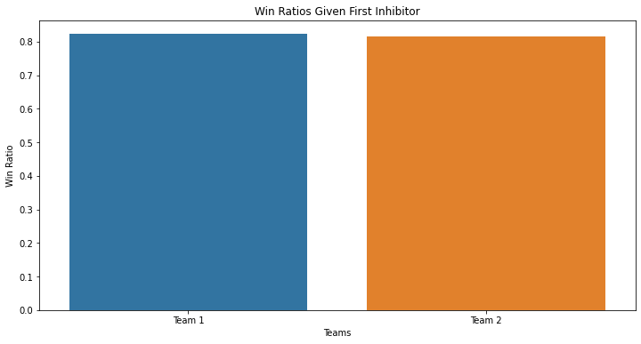

```python
# Calculate the win ratio for Team 1 ---------------------------------

# Get rows where winner and firstInhibitor are "1"
team1_data = new_data.loc[(new_data["winner"] == 1) & (new_data["firstInhibitor"] == 1)]

# Get rows to show how many wins team 1 had
team1_wins = new_data.loc[(new_data["winner"] == 1)]

# Get the numerator and denominator for the win ratio (this is done through the number of rows for each dataframe)
numerator = team1_data.shape[0]
denominator = team1_wins.shape[0]

# Calculate the win ratio
win_ratio_t1 = numerator / denominator


# Calculate the win ratio for Team 2 ---------------------------------

# Get rows where winner and firstInhibitor are "2"
team2_data = new_data.loc[(new_data["winner"] == 2) & (new_data["firstInhibitor"] == 2)]

# Get rows to show how many wins team 2 had
team2_wins = new_data.loc[(new_data["winner"] == 2)]

# Get the numerator and denominator for the win ratio (this is done through the number of rows for each dataframe)
numerator = team2_data.shape[0]
denominator = team2_wins.shape[0]

# Calculate the win ratio
win_ratio_t2 = numerator / denominator

# Create a DataFrame with the win ratios
df = pd.DataFrame({'Teams': ['Team 1', 'Team 2'], 'Win Ratio': [win_ratio_t1, win_ratio_t2]})

# Create a bar plot showing the win ratio for each group
plt.figure(figsize = (12, 6))

# Create a bar plot
sns.barplot(x ='Teams', y ='Win Ratio', data = df)

# Set the title for the bar graph and label the axis
plt.title("Win Ratios Given First Inhibitor")
plt.ylabel('Win Ratio')
plt.xlabel('Teams')

# Show win percentages of each team given first tower
print("Win percentage of Team 1:", round(win_ratio_t1*100, 2), "%")
print("Win percentage of Team 2:", round(win_ratio_t2*100, 2), "%")

# To make graphs showable on the HTML document
pio.renderers.default = 'notebook'
```

Using this graph we can see there is a massive win rate if a team gets the first inhibitor. This makes a lot of sense since destroying the enemy teams Inhibitor signals that their end is near as this is one of the last lines of defense versus the opposing team. This graph tells us for example, that team 1 has around a **0.82 win ratio** when destroying team 2's inhibitor first, and team 2 has around a **0.81 win ratio** when destroying team 1's inhibitor first. What I found to be really interesting about this data is just how close the win ratios are. With the other graphs we saw common trends, such as 3% differences or so. But with first inhibitor it almost looks as if both teams are the same given how close their win ratios are. As mentioned before I did expect high ratios on this objective, but I didn't expect it to actually be this high. I was thinking more around the mid 70's or so.

**Winner vs firstBaron firstDragon firstRiftHerald**

[figure not shown]

Monsters such as [Dragons](https://leagueoflegends.fandom.com/wiki/Dragon), [Barons](https://tinyurl.com/yxxavufu), and [Rift Heralds](https://tinyurl.com/6pasmxrz) are neutral objectives on the map. Destroying these can give your team large amounts of gold and xp, as well as giving buffs to your team.

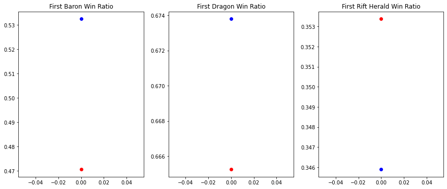

```python
# Calculate the win ratio for Team 1 --------------------------------------------

# Get rows where winner and firstBaron, firstDragon, and firstRiftHerald are "1"
team1_fb = new_data.loc[(new_data["winner"] == 1) & (new_data["firstBaron"] == 1)]
team1_fd = new_data.loc[(new_data["winner"] == 1) & (new_data["firstDragon"] == 1)]
team1_frh = new_data.loc[(new_data["winner"] == 1) & (new_data["firstRiftHerald"] == 1)]

# Get rows to show how many wins team 1 had
team1_wins = new_data.loc[(new_data["winner"] == 1)]

# Calculate the win ratios for all of the objectives for team 1
win_ratio_fb_t1 = team1_fb.shape[0] / team1_wins.shape[0]
win_ratio_fd_t1 = team1_fd.shape[0] / team1_wins.shape[0]
win_ratio_frh_t1 = team1_frh.shape[0] / team1_wins.shape[0]

# Calculate the win ratio for Team 2 ------------------------------------------

# Get rows where winner and firstBaron, firstDragon, and firstRiftHerald are "2"
team2_fb = new_data.loc[(new_data["winner"] == 2) & (new_data["firstBaron"] == 2)]
team2_fd = new_data.loc[(new_data["winner"] == 2) & (new_data["firstDragon"] == 2)]
team2_frh = new_data.loc[(new_data["winner"] == 2) & (new_data["firstRiftHerald"] == 2)]

# Get rows to show how many wins team 2 had
team2_wins = new_data.loc[(new_data["winner"] == 2)]

# Calculate the win ratios for all of the objectives for team 2
win_ratio_fb_t2 = team2_fb.shape[0] / team2_wins.shape[0]
win_ratio_fd_t2 = team2_fd.shape[0] / team2_wins.shape[0]
win_ratio_frh_t2 = team2_frh.shape[0] / team2_wins.shape[0]

# Graphing -------------------------------------------------------------------

# Create a figure and set the size
fig = plt.figure(figsize = (15, 6))

# Create a subplot with 1 row and 3 columns, and set the title
ax1 = fig.add_subplot(1, 3, 1, title = "First Baron Win Ratio")
ax2 = fig.add_subplot(1, 3, 2, title = "First Dragon Win Ratio")
ax3 = fig.add_subplot(1, 3, 3, title = "First Rift Herald Win Ratio")

# Add a point plot to each subplot
ax1.plot(win_ratio_fb_t1, "o", color = "r")
ax2.plot(win_ratio_fd_t1, "o", color = "r")
ax3.plot(win_ratio_frh_t1, "o", color = "r")

# Add a point plot to each subplot
ax1.plot(win_ratio_fb_t2, "o", color = "b")
ax2.plot(win_ratio_fd_t2, "o", color = "b")
ax3.plot(win_ratio_frh_t2, "o", color = "b")

# Show the plots
plt.show()

# To make graphs showable on the HTML document
pio.renderers.default = 'notebook'


# Show win percentages of each team given first tower
#print("Win percentage of Team 1:", "\n", "First Baron:", round(win_ratio_fb_t1*100, 2), "%\n", "First Dragon:", round(win_ratio_fd_t1*100, 2), "%\n", "First Rift Herald:", round(win_ratio_frh_t1*100, 2), "%")
#print("Win percentage of Team 2:", "\n", "First Baron:", round(win_ratio_fb_t2*100, 2), "%\n", "First Dragon:", round(win_ratio_fd_t2*100, 2), "%\n", "First Rift Herald:", round(win_ratio_frh_t2*100, 2), "%")
```

Here we created a figure with three subplots, one for each win ratio. The figure then adds point plots for the win ratios for team 1 and team 2 to each subplot. Our blue point indicates the win ratio for team 2 and our red point indicates the ratio for team 1. With this figure we are not using the x axis, so all points remain in the same horizontal position. The only information we care about here is the win ratios for each team for each object described above. What actually really interesting about this data is how spread apart the win ratios were for each team for First Baron. As we saw with our data above, the win ratios were relatively pretty close to each other as compared to these.

# **Predicting Win Ratio**

In this section, using the data we collected and fitted, and using the information we obtained in the last section, we want to **predict what team will win the game**. We want to determine this given certain things happen, such as first blood.

**Linear Regression For First Blood**

```python
# Create a new dataframe to edit using the old dataframes data
fb = new_data

# Drop all the columns we won't be using for this model
fb_df = fb.drop(['gameDuration', 'firstTower', 'firstInhibitor',	'firstBaron',	'firstDragon',	'firstRiftHerald',	't1_towerKills',	't1_inhibitorKills',	't1_baronKills',	't1_dragonKills',	't1_riftHeraldKills',
                 't2_towerKills',	't2_inhibitorKills',	't2_baronKills',	't2_dragonKills',	't2_riftHeraldKills'], axis = 1)

# Calculate the win ratio for Team 1 ---------------------------------

# Get rows where winner and firstBlood are "1"
team1_data = new_data.loc[(new_data["winner"] == 1) & (new_data["firstBlood"] == 1)]

# Get rows to show how many wins team 1 had
team1_wins = new_data.loc[(new_data["winner"] == 1)]

# Get the numerator and denominator for the win ratio (this is done through the number of rows for each dataframe)
numerator = team1_data.shape[0]
denominator = team1_wins.shape[0]

# Calculate the win ratio
win_ratio_t1 = numerator / denominator


# Calculate the win ratio for Team 2 ---------------------------------

# Get rows where winner and firstBlood are "2"
team2_data = new_data.loc[(new_data["winner"] == 2) & (new_data["firstBlood"] == 2)]

# Get rows to show how many wins team 2 had
team2_wins = new_data.loc[(new_data["winner"] == 2)]

# Get the numerator and denominator for the win ratio (this is done through the number of rows for each dataframe)
numerator = team2_data.shape[0]
denominator = team2_wins.shape[0]

# Calculate the win ratio
win_ratio_t2 = numerator / denominator

# Adding win ratios of teams 1 & 2 to the dataframe
fb_df["t1_win_ratio"] = win_ratio_t1
fb_df["t2_win_ratio"] = win_ratio_t2

fb_df.head()
```

|  | winner | firstBlood | t1_win_ratio | t2_win_ratio |
| --- | --- | --- | --- | --- |
| 0 | 1 | 2 | 0.602067 | 0.578742 |
| 1 | 1 | 1 | 0.602067 | 0.578742 |
| 2 | 1 | 2 | 0.602067 | 0.578742 |
| 3 | 1 | 1 | 0.602067 | 0.578742 |
| 4 | 1 | 2 | 0.602067 | 0.578742 |

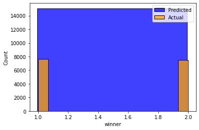

```python
# Select the columns we want to use as features
X = fb_df[["t1_win_ratio", "t2_win_ratio"]]

# Select the column we want to predict
y = fb_df["winner"]

# Create a LinearRegression object
lr = LinearRegression()

# Split the data into training and test sets
X_train, X_test, y_train, y_test = model_selection.train_test_split(X, y, test_size = 0.3)

# Fit the model on the training data
lr.fit(X_train, y_train)

# Use the model to make predictions on the test data
y_pred = lr.predict(X_test)

# Create a plot using seaborn's histplot function
sns.histplot(y_pred, color="blue", label="Predicted")
sns.histplot(y_test, color="orange", label="Actual")

# Add a legend
plt.legend()

# Show the plot
plt.show()

# To make graphs showable on the HTML document
pio.renderers.default = 'notebook'
```

**Decision Tree for First Blood**

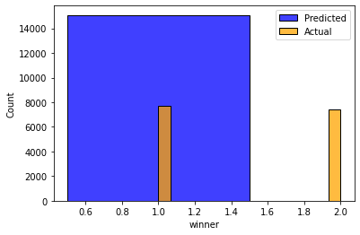

```python
# Select the columns we want to use as features
X = fb_df[["t1_win_ratio", "t2_win_ratio"]]

# Select the column we want to predict
y = fb_df["winner"]

# Create a DecisionTreeClassifier object
dt = DecisionTreeClassifier()

# Split the data into training and test sets
X_train, X_test, y_train, y_test = model_selection.train_test_split(X, y, test_size=0.3)

# Fit the model on the training data
dt.fit(X_train, y_train)

# Use the model to make predictions on the test data
y_pred = dt.predict(X_test)

# Create a plot using seaborn's histplot function
sns.histplot(y_pred, color="blue", label="Predicted")
sns.histplot(y_test, color="orange", label="Actual")

# Add a legend
plt.legend()

# Show the plot
plt.show()

# To make graphs showable on the HTML document
pio.renderers.default = 'notebook'
```

Next, we want to perform the F test to see if the model is a good fit for our data. To perform the F test, we need to first compute the sum of squares due to error (SSE), which is the sum of the squared differences between the predicted and actual values of the dependent variable. We can then compute the total sum of squares (SST), which is the sum of the squared differences between the mean of the dependent variable and the actual values. The F statistic is then calculated as the ratio of the mean squared error (MSE) to the variance of the dependent variable.

Once we have calculated the F statistic, we can compare it to a critical value from an F distribution table to determine whether the model provides a good fit for the data. If the calculated F statistic is greater than the critical value, we can conclude that the model provides a good fit for the data.

```python
# Compute the sum of squares due to error (SSE)
sse = sum((y_pred - y_test) ** 2)

# Compute the total sum of squares (SST)
mean_y = y_test.mean()
sst = sum((y_test - mean_y) ** 2)

# Compute the mean squared error (MSE)
mse = sse / len(y_pred)

# Compute the variance of the dependent variable
var_y = sst / len(y_test)

# Compute the F statistic
f = mse / var_y

# Get the critical value of F for a given confidence level
# and the degrees of freedom
confidence_level = 0.95
df1 = len(y_pred) - 1
df2 = len(y_test) - 1
critical_value = stats.f.ppf(confidence_level, df1, df2)

# Determine whether the model provides a good fit for the data
if f > critical_value:
    print("The model provides a good fit for the data.")
else:
    print("The model does not provide a good fit for the data.")
```

```
The model provides a good fit for the data.
```

Here we split the data into training and test sets. We then fit the decision tree model on the training data and used it to make predictions on the test data.

Next, we computed the SSE, SST, and MSE by summing the squared differences between the predicted and actual values of the dependent variable and dividing by the number of predicted values. We then computed the variance of the dependent variable and the F statistic by dividing the MSE by the variance.

Finally, we used the stats.f.ppf method to get the critical value of F for a given confidence level and degrees of freedom, and compared the calculated F statistic to the critical value to determine whether the model provides a good fit for the data. If the calculated F statistic is greater than the critical value, we can conclude that the model provides a good fit for the data.

# **Communication of Approach & Motivation**

**Communication of Approach**

In some cases, our data pointed to first inhibitor which skyrocketed the winrate to about 80%, plus or minus 1%, for each team. That's an absuredly high percentage.

But overall, we were only looking at a small portion of the dataset in this tutorial. Other columns, such as Dragon Kills, Rift Herald Kills, Tower Kills, and Inhibitor Kills for each team can play a big role in the game for choosing the winner. These objectives are the bulk of the game, so you might actually have an easier time predicitng a win with these objective columns. But as mentioned before, I was more motivated to learn how the other objectives impacted the outcome of the game.

**Motivation**

This data was very interesting to me since I personally have played league before. I'm very big into gaming and I play another MOBA called "Smite" which is similar to league in structure, but much smaller of a community and a different view. Regardless though there are a lot of similarities. This is where my motivation came into play for choosing the dataset that I did. I've always admired the structure of a MOBA and I've really enjoyed playing them. I've always wondered and thought about how high of an impact some of these objectives actually are in the game. So getting to do a final project based on this was right up my alley. I knew I would be more motivated to work on this, since it's something I enjoy and play, then the other datasets I was looking at.